# Lesson 20 RNASeq Sample QC

# Exploratory analysis and visualization

```r
library(tidyverse)
sampleData <- read_csv('sample_info.csv', col_names=TRUE)
countsData <- read_csv('counts_data.csv',col_names=TRUE)
```

```r
countsData = as.data.frame(countsData)
sampleData = as.data.frame(sampleData)
dds <- DESeqDataSetFromMatrix(countData = countsData,
                              colData = sampleData,
                              design = ~ dexamethasone,
                              tidy=TRUE
                             )
```

```
Warning: some variables in design formula are characters, converting to factors
```

## Pre-filtering the dataset

Our count matrix with our *DESeqDataSet* contains many rows with only zeros, and additionally many rows with only a few fragments total. In order to reduce the size of the object, and to increase the speed of our functions, we can remove the rows that have no or nearly no information about the amount of gene expression. Here we perform pre-filtering to keep only rows that have a count of at least 10 for a minimal number of samples. The count of 10 is a reasonable choice for bulk RNA-seq. A recommendation for the minimal number of samples is to specify the smallest group size, e.g. here there are 4 samples in each group. If there are not discrete groups, one can use the minimal number of samples where non-zero counts would be considered interesting. Additional weighting/filtering to improve power is applied at a later step in the workflow.

```r
nrow(dds)
```

```
[1] 64102
```

```r
smallestGroupSize <- 4
keep <- rowSums(counts(dds) >= 10) >= smallestGroupSize
dds <- dds[keep,]
nrow(dds)
```

```
[1] 16139
```

## The variance stabilizing transformation and the rlog

Many common statistical methods for exploratory analysis of multidimensional data, for example, *clustering* and *principal componentsanalysis* (PCA), work best for data that generally has the same range of variance at different ranges of the mean values. When the expected amount of variance is approximately the same across different mean values, the data is said to be *homoskedastic*. For RNA-seq counts, however, the expected variance grows with the mean. For example, if one performs PCA directly on a matrix of counts or normalized counts (e.g. correcting for differences in sequencing depth), the resulting plot typically depends mostly on the genes with *highest* counts because they show the largest absolute differences between samples.

A simple and often used strategy to avoid this is to take the logarithm of the normalized count values plus a pseudocount of 1; however, depending on the choice of pseudocount, now the genes with the very *lowest* counts will contribute a great deal of noise to the resulting plot, because taking the logarithm of small counts actually inflates their variance. We can quickly show this property of counts with some simulated data (here, Poisson counts with a range of lambda from 0.1 to 100). We plot the standard deviation of each row (genes) against the mean:

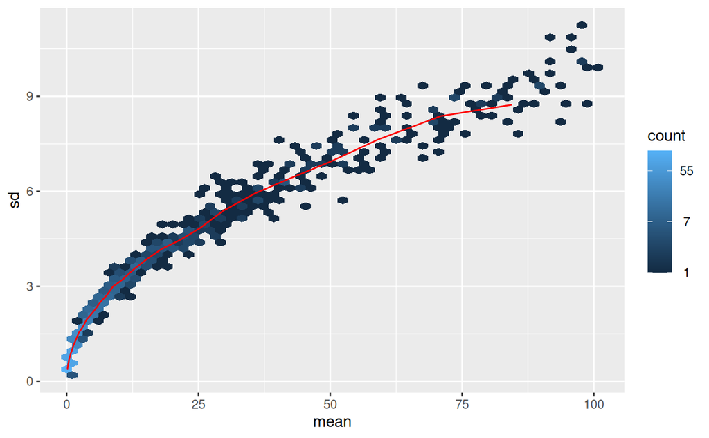

```r
lambda <- 10^seq(from = -1, to = 2, length = 1000)
cts <- matrix(rpois(1000*100, lambda), ncol = 100)
library("vsn")
meanSdPlot(cts, ranks = FALSE)
```

And for logarithm-transformed counts:

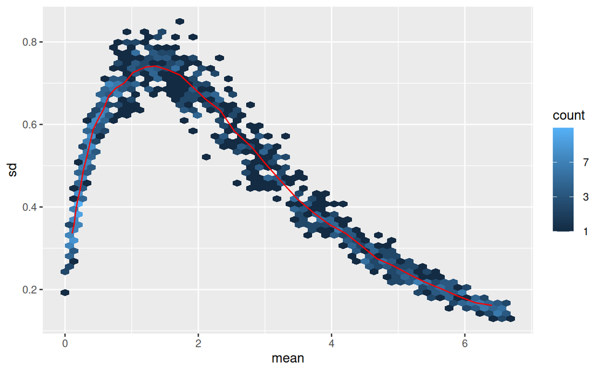

```r
log.cts.one <- log2(cts + 1)
meanSdPlot(log.cts.one, ranks = FALSE)
```

The logarithm with a small pseudocount amplifies differences when the values are close to 0. The low count genes with low signal-to-noise ratio will overly contribute to sample-sample distances and PCA plots.

As a solution, *DESeq2* offers two transformations for count data that stabilize the variance across the mean: the *variance stabilizing transformation* (VST) for negative binomial data with a dispersion-mean trend [@Anders2010Differential], implemented in the *vst* function, and the *regularized-logarithm transformation* or *rlog* [@Love2014Moderated].

For genes with high counts, both the VST and the rlog will give similar result to the ordinary log2 transformation of normalized counts. For genes with lower counts, however, the values are shrunken towards a middle value. The VST or rlog-transformed data then become approximately homoskedastic (more flat trend in the *meanSdPlot*), and can be used directly for computing distances between samples, making PCA plots, or as input to downstream methods which perform best with homoskedastic data.

**Which transformation to choose?** The VST is much faster to compute and is less sensitive to high count outliers than the rlog. The rlog tends to work well on small datasets (n < 30), potentially outperforming the VST when there is a wide range of sequencing depth across samples (an order of magnitude difference). We therefore recommend the VST for medium-to-large datasets (n > 30). You can perform both transformations and compare the `meanSdPlot` or PCA plots generated, as described below.

Note that the two transformations offered by DESeq2 are provided for applications *other* than differential testing.

For differential testing, the *DESeq* function applies to raw counts, which also takes into account the dependence of the variance of counts on the mean value during the dispersion estimation step.

Both *vst* and *rlog* return a *DESeqTransform* object which is based on the *SummarizedExperiment* class. The transformed values are no longer counts, and are stored in the *assay* slot. The *colData* that was attached to `dds` is still accessible:

```r
vsd <- vst(dds, blind = FALSE)
head(assay(vsd), 3)
```

```
                SRR1039508 SRR1039509 SRR1039512 SRR1039513 SRR1039516 SRR1039517 SRR1039520 SRR1039521
ENSG00000000003   9.645556   9.310241   9.782584   9.544040  10.111804   9.790193   9.933448   9.533876
ENSG00000000419   9.207602   9.472616   9.375478   9.412641   9.308992   9.464974   9.202705   9.394163
ENSG00000000457   8.585082   8.509292   8.461300   8.549454   8.393070   8.513736   8.584360   8.537161
```

```r
colData(vsd)
```

```
DataFrame with 8 rows and 4 columns
                sample    cellLine dexamethasone sizeFactor
           <character> <character>      <factor>  <numeric>
SRR1039508  SRR1039508      N61311     untreated   1.021977
SRR1039509  SRR1039509      N61311     treated     0.896072
SRR1039512  SRR1039512     N052611     untreated   1.173979
SRR1039513  SRR1039513     N052611     treated     0.668368
SRR1039516  SRR1039516     N080611     untreated   1.175368
SRR1039517  SRR1039517     N080611     treated     1.399261
SRR1039520  SRR1039520     N061011     untreated   0.916517
SRR1039521  SRR1039521     N061011     treated     0.945065
```

Again, for the *rlog*:

```r
rld <- rlog(dds, blind = FALSE)
head(assay(rld), 3)
```

```
                SRR1039508 SRR1039509 SRR1039512 SRR1039513 SRR1039516 SRR1039517 SRR1039520 SRR1039521
ENSG00000000003   9.397175   9.114493   9.512103   9.312771   9.786402   9.518592   9.637623   9.303347
ENSG00000000419   8.894651   9.121754   9.039030   9.070366   8.981886   9.115845   8.890702   9.054937
ENSG00000000457   7.952776   7.883440   7.839017   7.919734   7.775711   7.887471   7.951897   7.908930
```

To show the effect of the transformation, in the figure below we plot the first sample against the second, first simply using the *log2* function (after adding 1, to avoid taking the log of zero), and then using the VST and rlog-transformed values. For the *log2* approach, we need to first estimate *size factors* to account for sequencing depth, and then specify `normalized=TRUE`. Sequencing depth correction is done automatically for the *vst* and *rlog*.

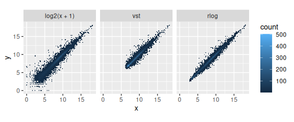

```r
library("dplyr")
library("ggplot2")

dds <- estimateSizeFactors(dds)

df <- bind_rows(
  as_data_frame(log2(counts(dds, normalized=TRUE)[, 1:2]+1)) %>%
         mutate(transformation = "log2(x + 1)"),
  as_data_frame(assay(vsd)[, 1:2]) %>% mutate(transformation = "vst"),
  as_data_frame(assay(rld)[, 1:2]) %>% mutate(transformation = "rlog"))

colnames(df)[1:2] <- c("x", "y")

lvls <- c("log2(x + 1)", "vst", "rlog")
df$transformation <- factor(df$transformation, levels=lvls)

ggplot(df, aes(x = x, y = y)) + geom_hex(bins = 80) +
  coord_fixed() + facet_grid( . ~ transformation)
```

**Scatterplot of transformed counts from two samples**. Shown are scatterplots using the log2 transform of normalized counts (left), using the VST (middle), and using the rlog (right). While the rlog is on roughly the same scale as the log2 counts, the VST has a upward shift for the smaller values. It is the differences between samples (deviation from y=x in these scatterplots) which will contribute to the distance calculations and the PCA plot.

We can see how genes with low counts (bottom left-hand corner) seem to be excessively variable on the ordinary logarithmic scale, while the VST and rlog compress differences for the low count genes for which the data provide little information about differential expression.

## Sample distances

A useful first step in an RNA-seq analysis is often to assess overall similarity between samples:

- Which samples are similar to each other?
- Which are different?
- Does this fit to the expectation from the experiment’s design?

We use the R function *dist* to calculate the Euclidean distance between samples. To ensure we have a roughly equal contribution from all genes, we use it on the VST data. We need to transpose the matrix of values using *t*, because the *dist* function expects the different samples to be rows of its argument, and different dimensions (here, genes) to be columns.

```r
sampleDists <- dist(t(assay(vsd)))
sampleDists
```

```
           SRR1039508 SRR1039509 SRR1039512 SRR1039513 SRR1039516 SRR1039517 SRR1039520
SRR1039509   44.44064
SRR1039512   36.68765   52.65865
SRR1039513   61.09340   43.00573   47.81152
SRR1039516   41.51940   56.39783   40.42681   61.58302
SRR1039517   61.33512   48.43658   55.78984   47.07596   45.78361
SRR1039520   36.90425   55.24648   33.73717   56.71192   43.19788   60.22922
SRR1039521   61.09833   42.83625   55.32319   34.12408   62.68595   48.88793   49.02408
```

We visualize the distances in a heatmap in a figure below, using the function *pheatmap* from the *pheatmap* package.

```r
library("pheatmap")
library("RColorBrewer")
```

In order to plot the sample distance matrix with the rows/columns arranged by the distances in our distance matrix, we manually provide `sampleDists` to the `clustering_distance` argument of the *pheatmap* function. Otherwise the *pheatmap* function would assume that the matrix contains the data values themselves, and would calculate distances between the rows/columns of the distance matrix, which is not desired. We also manually specify a blue color palette using the *colorRampPalette* function from the *RColorBrewer* package.

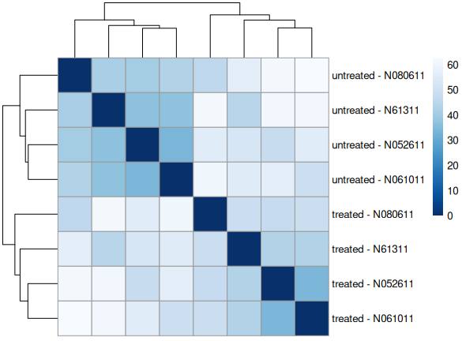

```r
sampleDistMatrix <- as.matrix( sampleDists )
rownames(sampleDistMatrix) <- paste( vsd$dexamethasone, vsd$cellLine, sep = " - " )
colnames(sampleDistMatrix) <- NULL
colors <- colorRampPalette( rev(brewer.pal(9, "Blues")) )(255)
pheatmap(sampleDistMatrix,
         clustering_distance_rows = sampleDists,
         clustering_distance_cols = sampleDists,
         col = colors)
```

**Heatmap of sample-to-sample distances using the variance stabilizing transformed values.**

Note that we have changed the row names of the distance matrix to contain treatment type and patient number instead of sample ID, so that we have all this information in view when looking at the heatmap.

Another option for calculating sample distances is to use the *Poisson Distance* [@Witten2011Classification], implemented in the *PoiClaClu* package. This measure of dissimilarity between counts also takes the inherent variance structure of counts into consideration when calculating the distances between samples. The *PoissonDistance* function takes the original count matrix (not normalized) with samples as rows instead of columns, so we need to transpose the counts in `dds`.

```r
library("PoiClaClu")
poisd <- PoissonDistance(t(counts(dds)))
```

We plot the heatmap in a Figure below.

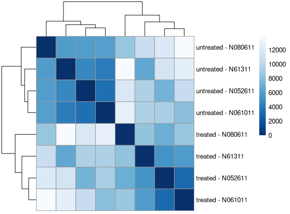

```r
samplePoisDistMatrix <- as.matrix( poisd$dd )
rownames(samplePoisDistMatrix) <- paste( dds$dexamethasone, dds$cellLine, sep=" - " )
colnames(samplePoisDistMatrix) <- NULL
pheatmap(samplePoisDistMatrix,
         clustering_distance_rows = poisd$dd,
         clustering_distance_cols = poisd$dd,
         col = colors)
```

**Heatmap of sample-to-sample distances using the *Poisson Distance*.**

## PCA plot

Another way to visualize sample-to-sample distances is a principal components analysis (PCA). In this ordination method, the data points (here, the samples) are projected onto the 2D plane such that they spread out in the two directions that explain most of the differences (figure below). The x-axis is the direction that separates the data points the most. The values of the samples in this direction are written *PC1*. The y-axis is a direction (it must be *orthogonal* to the first direction) that separates the data the second most. The values of the samples in this direction are written *PC2*. The percent of the total variance that is contained in the direction is printed in the axis label. Note that these percentages do not add to 100%, because there are more dimensions that contain the remaining variance (although each of these remaining dimensions will explain less than the two that we see).

```
using ntop=500 top features by variance
```

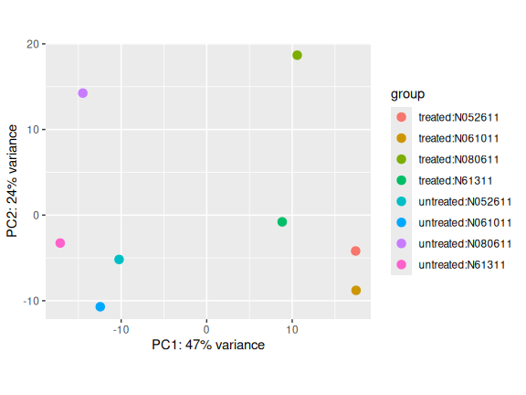

```r
plotPCA(vsd, intgroup = c("dexamethasone", "cellLine"))
```

**PCA plot using the VST data.** Each unique combination of treatment and cell line is given its own color.

Here, we have used the function *plotPCA* that comes with *DESeq2*. The two terms specified by `intgroup` are the interesting groups for labeling the samples; they tell the function to use them to choose colors. We can also build the PCA plot from scratch using the *ggplot2* package [@Wickham2009Ggplot2]. This is done by asking the *plotPCA* function to return the data used for plotting rather than building the plot. See the *ggplot2* [documentation](http://docs.ggplot2.org/current/) for more details on using *ggplot*.

```r
pcaData <- plotPCA(vsd, intgroup = c( "dexamethasone", "cellLine"), returnData = TRUE)
```

```
using ntop=500 top features by variance
```

```r
pcaData
```

|  | PC1 | PC2 | group | name | sample | cellLine | dexamethasone | sizeFactor |
| --- | --- | --- | --- | --- | --- | --- | --- | --- |
| SRR1039508 | -17.12660 | -3.2651390 | untreated:N61311 | SRR1039508 | SRR1039508 | N61311 | untreated | 1.0219766 |
| SRR1039509 | 8.82796 | -0.7896562 | treated:N61311 | SRR1039509 | SRR1039509 | N61311 | treated | 0.8960716 |
| SRR1039512 | -10.24095 | -5.1824349 | untreated:N052611 | SRR1039512 | SRR1039512 | N052611 | untreated | 1.1739790 |
| SRR1039513 | 17.41595 | -4.1911709 | treated:N052611 | SRR1039513 | SRR1039513 | N052611 | treated | 0.6683683 |
| SRR1039516 | -14.48328 | 14.2460091 | untreated:N080611 | SRR1039516 | SRR1039516 | N080611 | untreated | 1.1753681 |
| SRR1039517 | 10.58453 | 18.6733976 | treated:N080611 | SRR1039517 | SRR1039517 | N080611 | treated | 1.3992613 |
| SRR1039520 | -12.44463 | -10.7015210 | untreated:N061011 | SRR1039520 | SRR1039520 | N061011 | untreated | 0.9165167 |
| SRR1039521 | 17.46702 | -8.7894846 | treated:N061011 | SRR1039521 | SRR1039521 | N061011 | treated | 0.9450647 |

```r
percentVar <- round(100 * attr(pcaData, "percentVar"))
```

We can then use these data to build up a second plot in a figure below, specifying that the color of the points should reflect dexamethasone treatment and the shape should reflect the cell line.

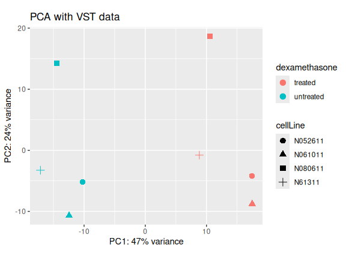

```r
ggplot(pcaData, aes(x = PC1, y = PC2, color = dexamethasone, shape = cellLine)) +
  geom_point(size =3) +
  xlab(paste0("PC1: ", percentVar[1], "% variance")) +
  ylab(paste0("PC2: ", percentVar[2], "% variance")) +
  coord_fixed() +
  ggtitle("PCA with VST data")
```

**PCA plot using the VST values with custom *ggplot2* code.** Here we specify cell line (plotting symbol) and dexamethasone treatment (color).

## PCA plot using Generalized PCA

Another technique for performing dimension reduction on data that is not Normally distributed (e.g. over-dispersed count data) is *generalized principal component analysis*, or GLM-PCA, [@Townes2019] as implemented in the CRAN package *glmpca*. This package takes as input the count matrix, as well as the number of latent dimensions to fit (here, we specify 2). As stated by @Townes2019:

> …we propose the use of GLM-PCA, a generalization of PCA to exponential family likelihoods. GLM-PCA operates on raw counts, avoiding the pitfalls of normalization. We also demonstrate that applying PCA to deviance or Pearson residuals provides a useful and fast approximation to GLM-PCA.

```r
library("glmpca")
gpca <- glmpca(counts(dds), L=2)
gpca.dat <- gpca$factors
gpca.dat$dexamethasone <- dds$dexamethasone
gpca.dat$cellLine <- dds$cellLine
```

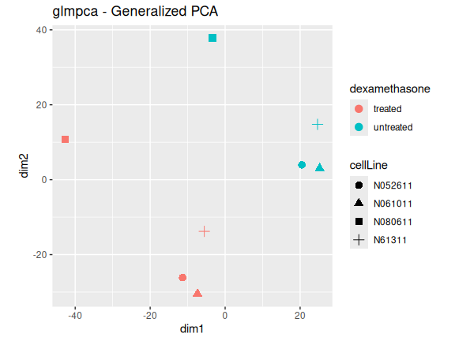

```r
ggplot(gpca.dat, aes(x = dim1, y = dim2, color = dexamethasone, shape = cellLine)) +
  geom_point(size =3) + coord_fixed() + ggtitle("glmpca - Generalized PCA")
```

## MDS plot

Another plot, very similar to the PCA plot, can be made using the *multidimensional scaling* (MDS) function in base R. This is useful when we don’t have a matrix of data, but only a matrix of distances. Here we compute the MDS for the distances calculated from the *VST* data and plot these in a figure below.

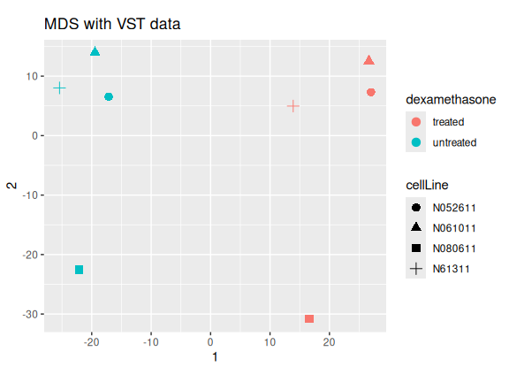

```r
mds <- as.data.frame(colData(vsd))  %>%
         cbind(cmdscale(sampleDistMatrix))
ggplot(mds, aes(x = `1`, y = `2`, color = dexamethasone, shape = cellLine)) +
  geom_point(size = 3) + coord_fixed() + ggtitle("MDS with VST data")
```

**MDS plot using VST data.**

```r
mdsPois <- as.data.frame(colData(dds)) %>%
   cbind(cmdscale(samplePoisDistMatrix))
ggplot(mdsPois, aes(x = `1`, y = `2`, color = dexamethasone, shape = cellLine)) +
  geom_point(size = 3) + coord_fixed() + ggtitle("MDS with PoissonDistances")
```

[output not shown]

—-

## Gene clustering

Using the Results calculated in Lesson 19

In the sample distance heatmap made previously, the dendrogram at the side shows us a hierarchical clustering of the samples. Such a clustering can also be performed for the genes. Since the clustering is only relevant for genes that actually carry a signal, one usually would only cluster a subset of the most highly variable genes. Here, for demonstration, let us select the 20 genes with the highest variance across samples. We will work with the VST data.

```r
library("genefilter")
topVarGenes <- head(order(rowVars(assay(vsd)), decreasing = TRUE), 20)
```

The heatmap becomes more interesting if we do not look at absolute expression strength but rather at the amount by which each gene deviates in a specific sample from the gene’s average across all samples. Hence, we center each genes’ values across samples, and plot a heatmap (figure below). We provide a *data.frame* that instructs the *pheatmap* function how to label the columns.

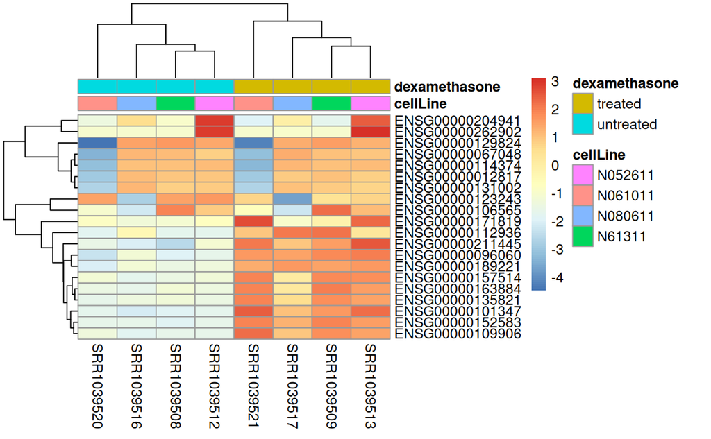

```r
mat  <- assay(vsd)[ topVarGenes, ]
mat  <- mat - rowMeans(mat)
anno <- as.data.frame(colData(vsd)[, c("cellLine","dexamethasone")])
pheatmap(mat, annotation_col = anno)
```